# Best Practices in Writing Reproducible Code in R

Cognitive Neuroscience Center (CNC)

Diego Angeles-Valdez

02 juni, 2025

## The Dataset

The **SUDMEX TMS** dataset is a randomised, double-blind, longitudinal trial involving 54 Mexican patients with CUD undergoing rTMS treatment. Data were collected at five time points over the course of a year and included demographic, clinical, cognitive and multimodal *MRI measures (structural, functional and diffusion)* [Angeles-Valdez, et.al., 2024](https://www.nature.com/articles/s41597-024-03242-y#citeas).

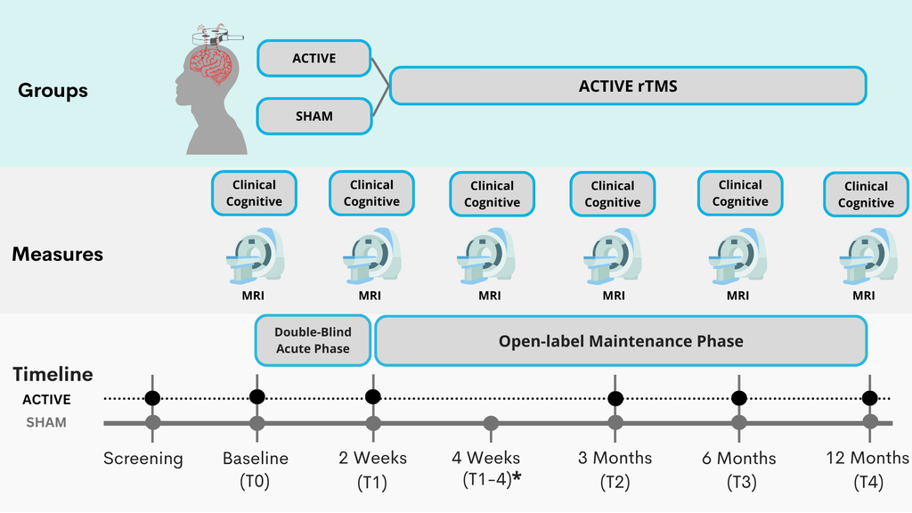

## Load R packages

```r
library(pacman)
pacman::p_load(tidyverse, # Data manipulation, visualization and description data.
                  summarytools, # Data cleaning, exploring, and simple reporting.
               )
```

```
##
## Your package installed
```

## Load data

```r
data <- read.csv("../data/SUDMEX_BIS.csv")
```

## Data structure

**str command**

```r
str(data)
```

```
## 'data.frame':    153 obs. of  37 variables:
##  $ rid      : int  1 1 1 2 2 2 2 2 2 3 ...
##  $ group    : int  1 1 1 1 1 1 1 1 1 2 ...
##  $ stage    : chr  "T0" "T1" "T4" "T0" ...
##  $ q1       : int  0 0 4 4 4 4 4 3 1 1 ...
##  $ q2       : int  4 1 1 1 3 0 0 3 1 3 ...
##  $ q3       : int  0 0 0 4 4 4 3 4 4 1 ...
##  $ q4       : int  4 4 4 4 4 4 4 4 3 3 ...
##  $ q5       : int  4 3 0 4 4 4 4 3 3 3 ...
##  $ q6       : int  0 1 0 4 3 4 4 1 3 0 ...
##  $ q7       : int  0 0 0 3 1 3 3 0 3 3 ...
##  $ q8       : int  0 0 4 4 4 3 4 1 4 0 ...
##  $ q9       : int  0 0 1 4 4 4 4 4 3 1 ...
##  $ q10      : int  0 0 1 1 3 3 3 1 4 1 ...
##  $ q11      : int  4 1 4 3 3 3 4 3 4 0 ...
```

[output cut: 23 more lines]

**glimpse command**

```r
glimpse(data)
```

```
## Rows: 153
## Columns: 37
## $ rid       <int> 1, 1, 1, 2, 2, 2, 2, 2, 2, 3, 3, 3, 3, 4, 4, 4, 4, 4, 5, 5, …
## $ group     <int> 1, 1, 1, 1, 1, 1, 1, 1, 1, 2, 2, 2, 2, 2, 2, 2, 2, 2, 1, 1, …
## $ stage     <chr> "T0", "T1", "T4", "T0", "T1", "T1-4", "T2", "T3", "T4", "T0"…
## $ q1        <int> 0, 0, 4, 4, 4, 4, 4, 3, 1, 1, 3, 3, 1, 0, 3, 4, 3, 1, 0, 3, …
## $ q2        <int> 4, 1, 1, 1, 3, 0, 0, 3, 1, 3, 1, 1, 3, 3, 1, 1, 1, 3, 1, 1, …
## $ q3        <int> 0, 0, 0, 4, 4, 4, 3, 4, 4, 1, 3, 1, 1, 0, 1, 1, 1, 4, 3, 3, …
## $ q4        <int> 4, 4, 4, 4, 4, 4, 4, 4, 3, 3, 3, 3, 3, 4, 4, 1, 1, 4, 3, 3, …
## $ q5        <int> 4, 3, 0, 4, 4, 4, 4, 3, 3, 3, 3, 1, 1, 0, 3, 1, 0, 0, 3, 4, …
## $ q6        <int> 0, 1, 0, 4, 3, 4, 4, 1, 3, 0, 1, 1, 1, 0, 3, 3, 1, 0, 3, 3, …
## $ q7        <int> 0, 0, 0, 3, 1, 3, 3, 0, 3, 3, 1, 1, 3, 0, 1, 3, 3, 3, 0, 1, …
## $ q8        <int> 0, 0, 4, 4, 4, 3, 4, 1, 4, 0, 1, 1, 1, 0, 3, 3, 1, 1, 0, 0, …
## $ q9        <int> 0, 0, 1, 4, 4, 4, 4, 4, 3, 1, 1, 3, 1, 0, 1, 3, 1, 1, 0, 3, …
## $ q10       <int> 0, 0, 1, 1, 3, 3, 3, 1, 4, 1, 1, 1, 1, 1, 1, 3, 1, 0, 0, 3, …
```

[output cut: 24 more lines]

## Explore the dataset

```r
#data %>% summarytools::dfSummary( method = "render")
#data %>%  group_by(group) %>% summarytools::dfSummary( method = "render")
```

*Note:* to display in html use stview()

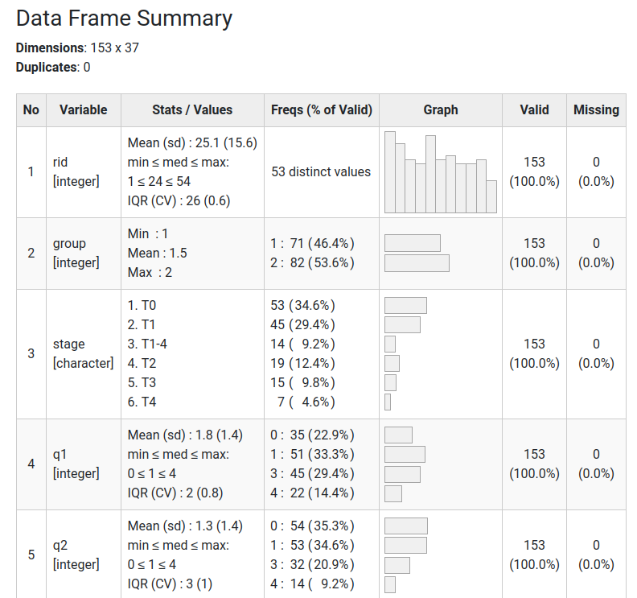

## dplyr functions

Tip: Have a dataset with all variables and create subdatasets from it

### Load package

```r
library(dplyr)
pacman::p_load(dplyr, # Data manipulation, visualization and description data.
               )
```

```
##
## Your package installed
```

### names()

```
##  [1] "rid"       "group"     "stage"     "q1"        "q2"        "q3"
##  [7] "q4"        "q5"        "q6"        "q7"        "q8"        "q9"
## [13] "q10"       "q11"       "q12"       "q13"       "q14"       "q15"
## [19] "q16"       "q17"       "q18"       "q19"       "q20"       "q21"
## [25] "q22"       "q23"       "q24"       "q25"       "q26"       "q27"
## [31] "q28"       "q29"       "q30"       "cog"       "mot"       "nonp"
## [37] "tot_score"
```

### select()

```r
data %>% select(rid, group, stage, q1, q2) %>%
  head(5)
```

```
##   rid group stage q1 q2
## 1   1     1    T0  0  4
## 2   1     1    T1  0  1
## 3   1     1    T4  4  1
## 4   2     1    T0  4  1
## 5   2     1    T1  4  3
```

```r
#data %>%  select(1:5)
#data %>% select(1,group, 4:7)
```

[output not shown]

[output not shown]

### select()

```r
data %>% select(cog, mot, nonp, tot_score) %>%
  head(5)
```

```
##   cog mot nonp tot_score
## 1  25  25   25        75
## 2  30  20   22        72
## 3  20  19   11        50
## 4  22  33   17        72
## 5  22  31   13        66
```

### filter()

```r
data %>% select(rid, group, tot_score) %>%
  filter(group ==1 ) %>%
  head(5)
```

```
##   rid group tot_score
## 1   1     1        75
## 2   1     1        72
## 3   1     1        50
## 4   2     1        72
## 5   2     1        66
```

```r
data %>% select(rid, stage, tot_score) %>%
  filter(stage =="T0")%>%
  head(5)
```

```
##   rid stage tot_score
## 1   1    T0        75
## 2   2    T0        72
## 3   3    T0        69
## 4   4    T0        85
## 5   5    T0        84
```

### filter()

```r
data %>% select(rid, stage, tot_score) %>%
  filter(stage !="T0") %>%
  head(5)
```

```
##   rid stage tot_score
## 1   1    T1        72
## 2   1    T4        50
## 3   2    T1        66
## 4   2  T1-4        47
## 5   2    T2        48
```

### filter() two condition

```r
data %>% select(rid, stage, tot_score) %>%
  filter(stage =="T0"| stage =="T1"  )%>%
  head(5)
```

```
##   rid stage tot_score
## 1   1    T0        75
## 2   1    T1        72
## 3   2    T0        72
## 4   2    T1        66
## 5   3    T0        69
```

### filter()

```r
data %>% select(rid, group, stage, tot_score) %>%
  filter(stage =="T0",  group ==1  )%>%
  head(5)
```

```
##   rid group stage tot_score
## 1   1     1    T0        75
## 2   2     1    T0        72
## 3   5     1    T0        84
## 4   6     1    T0        39
## 5   8     1    T0        47
```

### head, tail ()

```r
head(data, 4)
```

```
##   rid group stage q1 q2 q3 q4 q5 q6 q7 q8 q9 q10 q11 q12 q13 q14 q15 q16 q17
## 1   1     1    T0  0  4  0  4  4  0  0  0  0   0   4   0   0   1   0   0   0
## 2   1     1    T1  0  1  0  4  3  1  0  0  0   0   1   1   0   0   3   4   0
## 3   1     1    T4  4  1  0  4  0  0  0  4  1   1   4   4   4   0   4   1   0
## 4   2     1    T0  4  1  4  4  4  4  3  4  4   1   3   4   4   0   4   3   0
##   q18 q19 q20 q21 q22 q23 q24 q25 q26 q27 q28 q29 q30 cog mot nonp tot_score
## 1   4   0   0   4   0   4   1   4   1   4   4   4   4  25  25   25        75
## 2   4   0   0   3   3   3   3   1   1   3   3   1   3  30  20   22        72
## 3   4   0   0   0   1   1   4   0   0   0   0   0   4  20  19   11        50
## 4   4   1   1   4   4   4   4   0   4   4   4   4   1  22  33   17        72
```

```r
tail(data, 5)
```

```
##     rid group stage q1 q2 q3 q4 q5 q6 q7 q8 q9 q10 q11 q12 q13 q14 q15 q16 q17
## 149  53     2    T0  3  1  1  3  3  3  1  1  1   1   3   1   1   3   3   3   1
## 150  53     2    T1  3  0  1  0  1  3  4  3  3   3   3   0   1   0   0   1   0
## 151  54     2    T1  3  0  1  1  3  1  4  0  4   4   3   1   1   4   1   1   1
## 152  54     2    T0  4  1  1  3  1  1  1  0  0   1   0   1   1   3   3   3   0
## 153  54     2    T2  4  0  0  1  4  3  4  1  1   4   3   0   1   1   1   0   3
##     q18 q19 q20 q21 q22 q23 q24 q25 q26 q27 q28 q29 q30 cog mot nonp tot_score
## 149   3   1   1   1   3   3   3   1   3   3   1   3   1  24  20   20        64
## 150   3   3   1   0   4   4   3   0   3   3   4   1   1  12  15   19        46
## 151   1   1   0   0   3   3   3   4   3   0   3   3   1  11  19   26        56
## 152   1   1   1   0   1   1   1   1   3   1   1   1   0  20  14   29        63
## 153   1   4   0   0   4   4   3   1   1   0   3   1   1   7  10   13        30
```

### mutate()

```r
data %>%
  select(rid,tot_score) %>%
  mutate(New_total = tot_score) %>%
  mutate(Total2 = tot_score-5) %>%
  head(5)
```

```
##   rid tot_score New_total Total2
## 1   1        75        75     70
## 2   1        72        72     67
## 3   1        50        50     45
## 4   2        72        72     67
## 5   2        66        66     61
```

### mutate()

```r
data %>%
  select(rid, starts_with("q")) %>%
  rowwise() %>%
  mutate(Total = sum(across(starts_with("q")))) %>%
  head(5)
```

```
## # A tibble: 5 × 32
## # Rowwise:
##     rid    q1    q2    q3    q4    q5    q6    q7    q8    q9   q10   q11   q12
##   <int> <int> <int> <int> <int> <int> <int> <int> <int> <int> <int> <int> <int>
## 1     1     0     4     0     4     4     0     0     0     0     0     4     0
## 2     1     0     1     0     4     3     1     0     0     0     0     1     1
## 3     1     4     1     0     4     0     0     0     4     1     1     4     4
## 4     2     4     1     4     4     4     4     3     4     4     1     3     4
## 5     2     4     3     4     4     4     3     1     4     4     3     3     3
## # ℹ 19 more variables: q13 <int>, q14 <int>, q15 <int>, q16 <int>, q17 <int>,
## #   q18 <int>, q19 <int>, q20 <int>, q21 <int>, q22 <int>, q23 <int>,
## #   q24 <int>, q25 <int>, q26 <int>, q27 <int>, q28 <int>, q29 <int>,
## #   q30 <int>, Total <int>
```

### mutate()

```r
data %>%
  select(rid,group,tot_score) %>%
  mutate(New_group = case_when(group == 1 ~ "HC",
                           group ==  2 ~ "CUD"))%>%
  head(5)
```

```
##   rid group tot_score New_group
## 1   1     1        75        HC
## 2   1     1        72        HC
## 3   1     1        50        HC
## 4   2     1        72        HC
## 5   2     1        66        HC
```

Tip: Check R documentation with “?”

### arrange()

```r
data %>%
 select(rid,group,tot_score) %>%
 arrange(desc(tot_score))%>%
  head(5)
```

```
##   rid group tot_score
## 1  26     2        98
## 2  34     2        97
## 3  10     1        95
## 4  32     2        94
## 5  27     1        92
```

### summarise()

```r
data %>%
  select(rid,group,tot_score) %>%
  #group_by(group) %>%
  summarise(mean = mean(tot_score),
            sd = sd(tot_score))
```

```
##       mean       sd
## 1 57.89542 17.61435
```

### Always remember to give thanks

- [Grolemund, G., & Wickham, H. (2016). R for data science: Import, tidy, transform, visualize, and model data. O’Reilly Media.](https://r4ds.had.co.nz/)
- [Wickham, H., & Grolemund, G. (2017). Hands-on programming with R: Write your own functions and simulators. O’Reilly Media.](https://rstudio-education.github.io/hopr/)
- [Wickham, H. (2016). ggplot2: Elegant graphics for data analysis. Springer.](https://ggplot2-book.org/introduction.html)
- Field, A. (2013). Discovering statistics using R. SAGE Publications.
- [Poldrack, R. A. (2020). An R companion to Statistical Thinking for the 21st Century](https://statsthinking21.github.io/statsthinking21-R-site/)
- [Angeles-Valdez, D., Rasgado-Toledo, J., Villicaña, V. et al. The Mexican dataset of a repetitive transcranial magnetic stimulation clinical trial on cocaine use disorder patients: SUDMEX TMS. Sci Data 11, 408 (2024).](https://www.nature.com/articles/s41597-024-03242-y#citeas)

### Contact me

**M. Sc. Diego Angeles-Valdez,**  
**PhD Student,**  
University Medical Center Groningen, Cognitive Neuroscience Center,  
Biomedical Sciences of Cells and Systems (BCSS).  
Twitter: [@diegoangls](https://twitter.com/diegoangls)  
Email: d.angeles.valdez@umcg.nl | diego.ang.val@gmail.com  
Work address:P.O. Box 196, 9700 AD GRONINGEN, The Netherlands

[figure not shown]